# Log-Transforming the Outcome

Andrew Zieffler

February 24, 2021

## Preparation

```r
# Load libraries
library(broom)
library(educate)
library(lmtest)
library(patchwork)
library(tidyverse)

# Read in data
movies = read_csv(file = "~/Documents/github/epsy-8252/data/movies.csv")
head(movies)
```

```
# A tibble: 6 x 6
  title                 budget  year   age genre  length
  <chr>                  <dbl> <dbl> <dbl> <chr>   <dbl>
1 Trapped               41.9    2002    16 Other     106
2 Urbania                0.328  2000    18 Drama     106
3 End of Violence, The   7.82   1997    21 Drama     122
4 Snatch.               14.6    2000    18 Comedy    102
5 Narc                  10.5    2002    16 Drama     105
6 Kissing Jessica Stein  1.42   2001    17 Comedy     97
```

## Relationship between Budget and Running Time

To being the analysis, we will examine the marginal distributions of movie running time (predictor) and budget (outcome), as well as a scatterplot between them for our sample data.

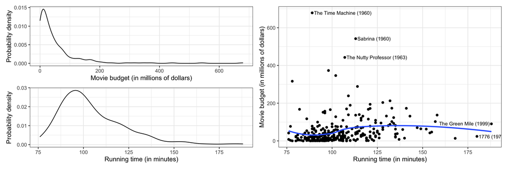

```r
# Marginal distribution of budget (outcome)
p1 = ggplot(data = movies, aes(x = budget)) +
  geom_density() +
  theme_bw() +
  xlab("Movie budget (in millions of dollars)") +
  ylab("Probability density")

# Marginal distribution of running time (predictor)
p2 = ggplot(data = movies, aes(x = length)) +
  geom_density() +
  theme_bw() +
  xlab("Running time (in minutes)") +
  ylab("Probability density")

# Scatterplot
p3 = ggplot(data = movies, aes(x = length, y = budget)) +
  geom_point() +
  geom_smooth(se = FALSE) +
  theme_bw() +
  xlab("Running time (in minutes)") +
  ylab("Movie budget (in millions of dollars)") +
  annotate(geom = "text", x = 90, y = 679, label = "The Time Machine (1960)", size = 3, hjust = 0) +
  annotate(geom = "text", x = 114, y = 542, label = "Sabrina (1960)", size = 3, hjust = 0) +
  annotate(geom = "text", x = 108, y = 443, label = "The Nutty Professor (1963)", size = 3, hjust = 0) +
  annotate(geom = "text", x = 181, y = 23, label = "1776 (1972)", size = 3, hjust = 0) +
  annotate(geom = "text", x = 187, y = 92, label = "The Green Mile (1999)", size = 3, hjust = 1)

# Place figures side-by-side
(p1 / p2) |  p3
```

The distribution of movie budgets is severely right-skewed. Although the median budget is around 25 million dollars, the plot shows evidence that several movies have exorbitant budgets. There is also one movie (*The Time Machine*) that has a budget of close to 680 million dollars; a budget that is over eight standard deviations higher than the median budget. The distribution of running time also appears right-skewed, with most movies clocking in at around 100 minutes. There are two movies in the sample that have a running time near three hours.

The scatterplot suggests a weak, slightly positive relationship between running time of a movie and budget. It also suggests several potential problems with fitting a linear model to the data:

- The relationship seems slightly curvilinear.
- The variation in budget for shorter movies is greater than the variation in budget for longer movies (heteroskedasticity).
- There are more data on the lower half of the plot than the upper half. This posits a potential problem with the normality assumption.

We can see these assumption violations much more clearly in the scatterplot of residuals versus fitted values we get from regressing movie budgets on running time.

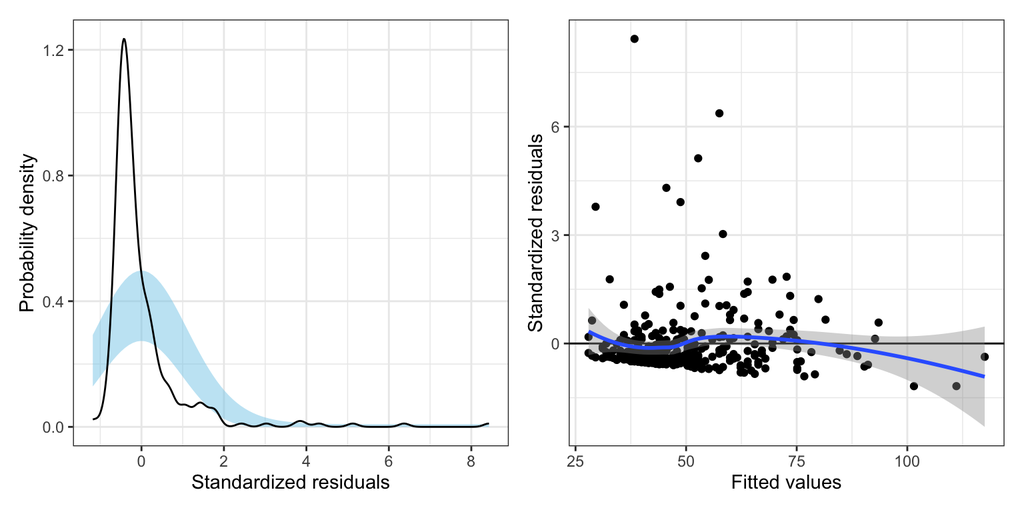

Density plot of the standardized residuals (left) and scatterplot of the standarized residuals versus the fitted values (right) from regressing budget on running time. The confidence envelope from assuming a normal distribution is also displayed along with the density plot. In the scatterplot, the loess smoother (solid, blue line) is displayed along with the 95% confidence envelope (grey shaded area) and the reference line of Y=0.

```r
# Fit model
lm.1 = lm(budget ~ 1 + length, data = movies)

# Obtain residuals and fitted values
out.1 = augment(lm.1)

# Density plot of the residuals
p1 = ggplot(data = out.1, aes(x = .std.resid)) +
  stat_density_confidence(model = "normal") +
  stat_density(geom = "line") +
  theme_bw() +
  xlab("Standardized residuals") +
  ylab("Probability density")

# Residuals versus fitted values
p2 = ggplot(data = out.1, aes(x = .fitted, y = .std.resid)) +
  geom_point() +
  geom_hline(yintercept = 0) +
  geom_smooth() +
  theme_bw() +
  xlab("Fitted values") +
  ylab("Standardized residuals")

# Plot the figures side-by-side
p1 | p2
```

These plots suggest violations of the normality assumption (the marginal distribution of the residuals is right-skewed) and of the assumption of homoskedasticity. The assumption that the average residual is 0, also may be in question, as the confidence envelope for the loess smoother deviates from the $Y=0$ line for fitted values between 50 and 70.

## Transform the Outcome Using the Natural Logarithm (Base-e)

To alleviate problems of non-normality when the conditional distributiona of the outcome are right-skewed (or have high-end outliers) OR to alleviate heteroskedasticity, we can mathematically transform the outcome using a logarithm. Any base can be used for the logarithm, but we will transform the outcome using the natural logarithm because of the interpretive value.

First, we will create the log-transformed budget as a new column in the data, and then we will use the log-transformed budget (rather than raw budget) in any analyses.

```r
# Create log-transformed budget
movies = movies %>%
  mutate(
    Lbudget = log(budget)
    )

# Examine data
head(movies)
```

```
# A tibble: 6 x 7
  title                 budget  year   age genre  length Lbudget
  <chr>                  <dbl> <dbl> <dbl> <chr>   <dbl>   <dbl>
1 Trapped               41.9    2002    16 Other     106   3.73
2 Urbania                0.328  2000    18 Drama     106  -1.11
3 End of Violence, The   7.82   1997    21 Drama     122   2.06
4 Snatch.               14.6    2000    18 Comedy    102   2.68
5 Narc                  10.5    2002    16 Drama     105   2.35
6 Kissing Jessica Stein  1.42   2001    17 Comedy     97   0.350
```

Recall that the logarithm is the inverse function of an exponent. As an example, consider the budget and natural log-transformed budget for the movie *Trapped*:

$$\ln(41.88) = 3.73$$

Remember, in this case, the logarithm answers the mathematical question:

##### Interpretation

$e$ to what power is equal to 41.88?

The answer to this question is:

$$e^{3.73} = 41.88$$

### Re-analyze using the Log-Transformed Budget

Now we will re-examine the scatterplot using the log-transformed outcome to see how this transformation affects the relationship between running time and budget.

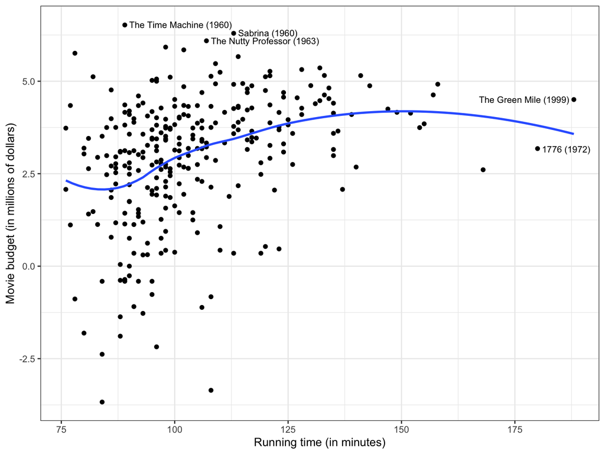

```r
# Scatterplot
ggplot(data = movies, aes(x = length, y = Lbudget)) +
  geom_point() +
  geom_smooth(se = FALSE) +
  theme_bw() +
  xlab("Running time (in minutes)") +
  ylab("Movie budget (in millions of dollars)") +
  annotate(geom = "text", x = 90, y = 6.53, label = "The Time Machine (1960)", size = 3, hjust = 0) +
  annotate(geom = "text", x = 114, y = 6.31, label = "Sabrina (1960)", size = 3, hjust = 0) +
  annotate(geom = "text", x = 108, y = 6.10, label = "The Nutty Professor (1963)", size = 3, hjust = 0) +
  annotate(geom = "text", x = 181, y = 3.17, label = "1776 (1972)", size = 3, hjust = 0) +
  annotate(geom = "text", x = 187, y = 4.51, label = "The Green Mile (1999)", size = 3, hjust = 1)
```

Log-transforming the outcome has drastically affected the scale for the outcome. The three movies which had extremely high budgets when we examined raw budget, no longer seems like outliers in the transformed data. Has this helped us better meet the distributional assumptions for the regression model? To find out, we will re-fit the model using the log-transformed budget and examine the residual plots.

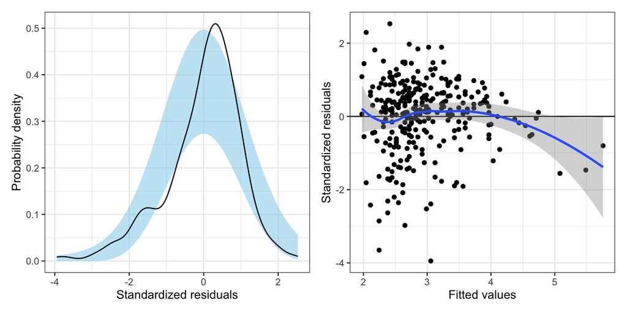

Density plot of the standardized residuals (left) and scatterplot of the standarized residuals versus the fitted values (right) from regressing log-transformed budget on running time. The confidence envelope from assuming a normal distribution is also displayed along with the density plot. In the scatterplot, the loess smoother (solid, blue line) is displayed along with the 95% confidence envelope (grey shaded area) and the reference line of Y=0.

```r
# Fit model
lm.2 = lm(Lbudget ~ 1 + length, data = movies)

# Obtain residuals and fitted values
out.2 = augment(lm.2)

# Density plot of the residuals
p1 = ggplot(data = out.2, aes(x = .std.resid)) +
  stat_density_confidence(model = "normal") +
  stat_density(geom = "line") +
  theme_bw() +
  xlab("Standardized residuals") +
  ylab("Probability density")

# Residuals versus fitted values
p2 = ggplot(data = out.2, aes(x = .fitted, y = .std.resid)) +
  geom_point() +
  geom_hline(yintercept = 0) +
  geom_smooth() +
  theme_bw() +
  xlab("Fitted values") +
  ylab("Standardized residuals")

# Plot the figures side-by-side
p1 | p2
```

These plots suggest that after the transformation, there is a great deal of improvement in meeting the assumption of normality, however there looks to still be some inconsistency with this assumption. The assumption of homoskedasticity now shows only minor violation, having improved over residuals from the non-transformed budget. (The biggest problems seems to be for movies with longer running times for which there are fewer observations; thus it might be a few observations driving this violation.) The assumption that the average residual is 0 now only shows deviation for fitted values greater than five, which, may be driven by the three movies with longer running times.

### Interpreting the Regression Output

Since the assumptions look better, we will adopt this model in which we regressed the log-transformed budget on running time, and examine the model- and coefficient-level output from the model.

```r
# Model-level output
print(glance(lm.2), width = Inf)
```

```
# A tibble: 1 x 12
  r.squared adj.r.squared sigma statistic  p.value    df logLik   AIC   BIC
      <dbl>         <dbl> <dbl>     <dbl>    <dbl> <dbl>  <dbl> <dbl> <dbl>
1     0.124         0.121  1.63      41.2 5.58e-10     1  -556. 1117. 1128.
  deviance df.residual  nobs
     <dbl>       <int> <int>
1     768.         290   292
```

The model-level summary information suggests that differences in running time explains 12.4% of the variation in budgets. (Remember, explaining variation in log-budget is the same as explaining variation in budget.)

```r
# Coefficient-level output
tidy(lm.2)
```

```
# A tibble: 2 x 5
  term        estimate std.error statistic  p.value
  <chr>          <dbl>     <dbl>     <dbl>    <dbl>
1 (Intercept)  -0.589    0.558       -1.05 2.93e- 1
2 length        0.0338   0.00526      6.42 5.58e-10
```

From the coefficient-level output, the fitted equation is:

$$\ln\left(\hat{\mathrm{Budget}_i}\right) = -0.59 + 0.034(\mathrm{Running~Time}_i)$$

With log-transformations, there are two possible interpretations we can offer. The first is to interpret the coefficients using the log-transformed metric. These we interpret in the exact same way we do any other regression coefficients (except we use log-outcome instead of outcome):

- The intercept, $\hat{\beta_0} = -0.59$, is the average predicted log-budget for movies with a running time of 0 minutes (extrapolation).
- The slope, $\hat{\beta_1} = 0.034$, indicates that each one-minute difference in running time is associated with a log-budget that differs by $0.034$, on average.

#### Back-Transforming: A More Useful Interpretation

A second, probably more useful, interpretation is to back-transform the metric of log-budget to the metric of raw budget. To think about how to do this, we first consider a more general expression of the fitted linear model:

$$\ln\left(\hat{Y}_i\right) = \hat\beta_0 + \hat\beta_1(X_{i})$$

The left-hand side of the equation is in the log-transformed metric, which drives our interpretations. If we want to instead, interpret using the raw metric of *Y*, we need to back-transform from $\ln(Y)$ to *Y*. To back-transform, we use the inverse function, which is to exponentiate using the base of the logarithm, in our case, base-*e*.

$$e^{\ln(Y_i)} = Y_i$$

If we exponentiate the left-hand side of the equation, to maintain the equality, we also need to exponentiate the right-hand side of the equation.

$$e^{\ln(Y_i)} = e^{\hat\beta_0 + \hat\beta_1(X_{i})}$$

Then we use rules of exponents to simplify this.

$$Y_i = e^{\hat\beta_0} \times e^{\hat\beta_1(X_{i})}$$

For our example, we exponentiate both sides of the fitted equation to get the following back-transformed fitted equation:

$$\hat{\mathrm{Budget}_i} = e^{-0.59} \times e^{0.034(\mathrm{Running~Time}_i)}$$

#### Substituting in Values for Running Time to Interpret Effects

To interpret the back-transformed effects, we can substitute in the different values for running time and solve. For example when running time = 0:

$$\begin{split}
\hat{\mathrm{Budget}_i} &= e^{-0.59} \times e^{0.034(0)}\\
&= 0.56 \times 1 \\
&= 0.56
\end{split}$$

The predicted budget for a movie that is 0 minutes long is 0.56 million dollars (extrapolation). How about a movie that is one minute long (a one-minute difference in running time from movies that are 0 minutes long)?

$$\begin{split}
\hat{\mathrm{Budget}_i} &= e^{-0.59} \times e^{0.034(1)}\\
&= 0.56 \times 1.034 \\
&= 0.57
\end{split}$$

The predicted budget for a movie that is one minute long is 0.57 million dollars. This is 1.034 TIMES the budget of a movie that is 0 minutes long. Rather than using the language of **TIMES difference** you could also use the language of **fold difference**. In this case the slope coefficient would be interpreted as,

##### Interpretation

Each one-minute difference in running time is associated with a 1.034-fold difference in budget, on average.

Simply put, when we back-transform from interpretations of log-*Y* to *Y* the interpretations are multiplicatively related to the intercept rather than additively related. We can obtain these multiplicative values (and the back-transformed intercept) by using the `exp()` function to exponentiate the coefficients from the fitted model, which we can obtain using the `coef()` function.

```r
# Obtain back-transformed interpretations
exp(coef(lm.2))
```

```
(Intercept)      length
  0.5550024   1.0343293
```

### Approximate Interpretation of the Slope as Percent Change

Remember from the previous set of notes, that by using the natural logarithm we can interpret the effects as *percent change*. Rather than saying that each one-minute difference in running time is associated with a 1.034-fold difference in budget, on average, we can directly interpret the slope as the percent change. Thus $\hat{\beta_1}=0.034$ can be interpreted as:

##### Interpretation

Each one-minute difference in running time is associated with a 3.4 percent increase in budget, on average.

This is an approximation that is often “good enough” for low values of the slope (e.g., $\hat\beta_k < 0.20$).

If you use the language of percent change, be very careful. *Percent* and *Percent change* typically indicate differing amounts! For instance, consider two movie budgets, one is 20 million dollars and the other is 15 million dollars. The movie with the 15 million dollar budget has a budget that is 75% of the movie that has a 20 million dollar budget. However, the percent change in budgets is 25%.

### Plotting the Fitted Model

As always, we should plot the fitted model to aid in interpretation. To do this we will use the back-transformed expression of the fitted equation:

$$\hat{\mathrm{Budget}_i} = e^{-0.59} \times e^{0.034(\mathrm{Running~Time}_i)}$$

This can be added to the `geom_function()` layer of `ggplot()`.

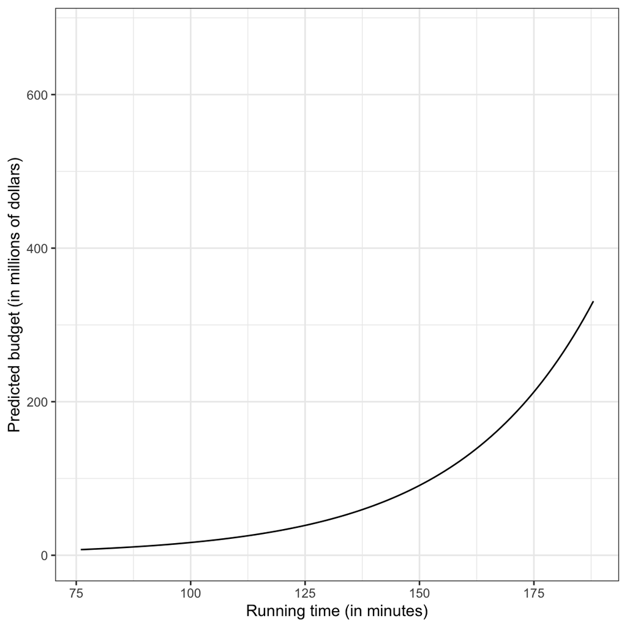

Plot of predicted budget as a function of running time.

```r
# Plot
ggplot(data = movies, aes(x = length, y = budget)) +
  geom_point(alpha = 0) +
  geom_function(fun = function(x) {exp(-0.59) * exp(0.034*x)} ) +
  theme_bw() +
  xlab("Running time (in minutes)") +
  ylab("Predicted budget (in millions of dollars)")
```

Based on this plot, we see a non-linear, positive effect of running time on budget. Shorter movies tend to have a smaller budget, on average, but the increase in budget as movies get longer is not constant. This pattern of non-linear increase is referred to as *positive exponential growth* (it has a positive increasing rate of growth). This pattern is different than what we saw in the fitted equation for the college data from the previous unit, which could be described as *positive exponential decay* (positive diminishing rates of growth). However, both of these effects are described by *monotonic* functions which have no change in the direction; both were always increasing (positive).

## Modeling the Remaining Non-Linearity

How do we model the non-linearity we observed in the relationship even after we log-transformed the outcome?

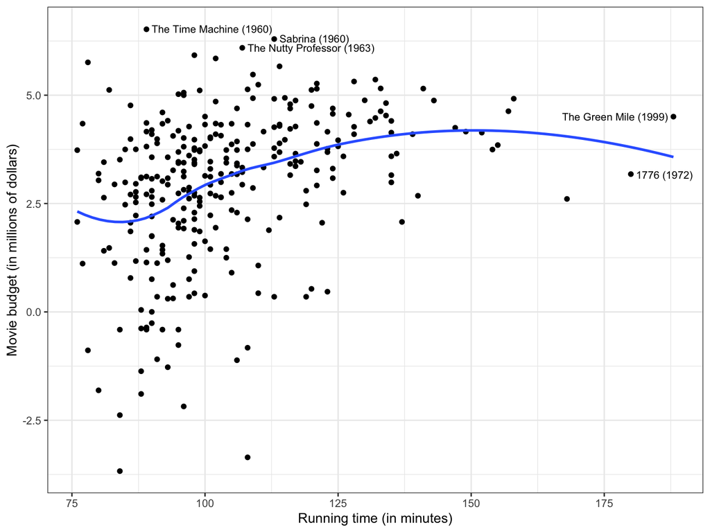

The pattern in the scatterplot shown by the loess smoother in the plot, suggests a curvilinear pattern similar to what we observed in the college data in previous sets of notes. This means we can try to model the non-linearity by: (1) log-transforming the predictor (in addition to log-transforming the outcome), or (2) include a polynomial effect of running time in the model. How do you choose? Fit both models and examine the residuals.

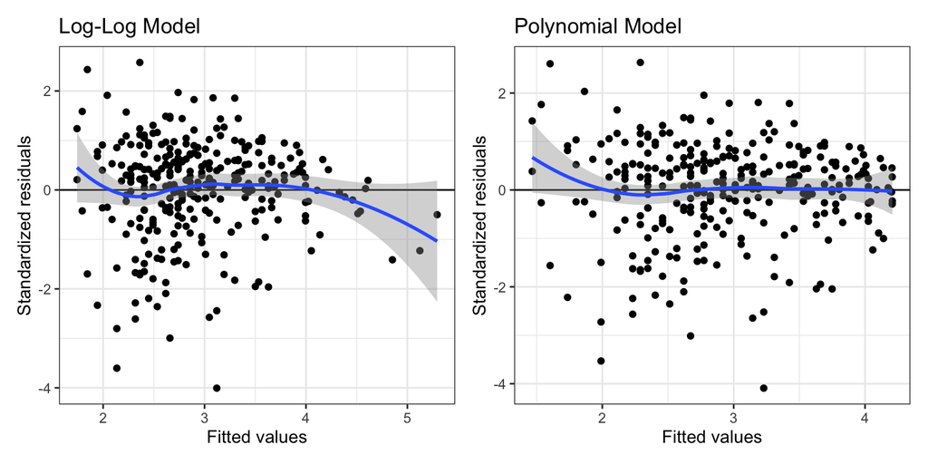

Standardized residuals versus the fitted values for the model using the natural logarithm of running time (left) and for the model that includes a linear and quadratic effect of running time (right) to predict variation in log-budget. The loess smoother and confidence envelope for the smoother is also included in both plots.

```r
# Fit log-log model
lm.log = lm(Lbudget ~ 1 + log(length), data = movies)

# Fit polynomial model
lm.poly = lm(Lbudget ~ 1 + length + I(length^2), data = movies)

# Obtain residuals
out.log = augment(lm.log)
out.poly = augment(lm.poly)

# Log-log residuals
p1 = ggplot(data = out.log, aes(x = .fitted, y = .std.resid)) +
  geom_point() +
  geom_hline(yintercept = 0) +
  geom_smooth() +
  theme_bw() +
  xlab("Fitted values") +
  ylab("Standardized residuals") +
  ggtitle("Log-Log Model")

# Polynomial model residuals
p2 = ggplot(data = out.poly, aes(x = .fitted, y = .std.resid)) +
  geom_point() +
  geom_hline(yintercept = 0) +
  geom_smooth() +
  theme_bw() +
  xlab("Fitted values") +
  ylab("Standardized residuals") +
  ggtitle("Polynomial Model")

# Plot side-by-side
p1 | p2
```

Based on the residual plots, the polynomial model seems to show better fit to the assumption that the average residual is 0 than the log-log model. We can also see this by comparing the fit of each model to the pattern modeled by the loess smoother in the scatterplot of the log-budgets versus the running times. To do this we would need to obtain the coefficient-level output for each fitted model and then use `geom_function()` to include the fitted curve onto the scatterplot.

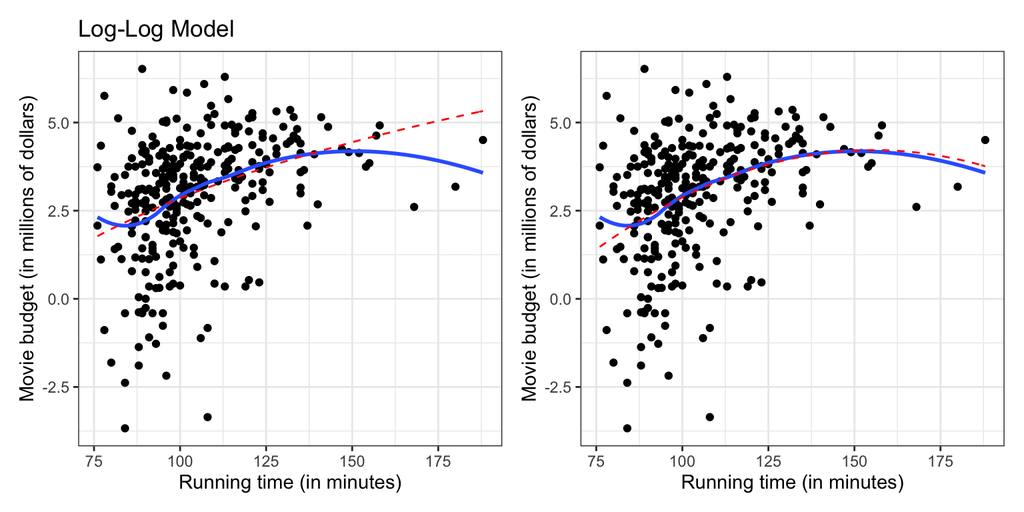

```r
# Log-log model
p1 = ggplot(data = movies, aes(x = length, y = Lbudget)) +
  geom_point() +
  geom_smooth(se = FALSE) +
  geom_function(fun = function(x) {log(exp(-15.2) * x^(3.92))},
                color = "red", linetype = "dashed") +
  theme_bw() +
  xlab("Running time (in minutes)") +
  ylab("Movie budget (in millions of dollars)") +
  ggtitle("Log-Log Model")

# polynomial model
p2 = ggplot(data = movies, aes(x = length, y = Lbudget)) +
  geom_point() +
  geom_smooth(se = FALSE) +
  geom_function(fun = function(x) {-6.28 + 0.135*x - 0.000434*x^2},
                color = "red", linetype = "dashed") +
  theme_bw() +
  xlab("Running time (in minutes)") +
  ylab("Movie budget (in millions of dollars)")

# Plot side-by-side
p1 | p2
```

The polynomial model shows better adherance to the pattern captured by the loess smoother than the log-log model. Thus, we will adopt the polynomial model over the log-log model. We can also evaluate both the linear and quadratic effects of running time by using the likelihood ratio test to compare a series of candidate models with increasing complexity.

```r
# Fit the intercept-only model
lm.0 = lm(Lbudget ~ 1, data = movies)

# Likelihood ratio test to evaluate effects of running time
lrtest(lm.0, lm.1, lm.poly)
```

```
Likelihood ratio test

Model 1: Lbudget ~ 1
Model 2: budget ~ 1 + length
Model 3: Lbudget ~ 1 + length + I(length^2)
  #Df   LogLik Df  Chisq Pr(>Chisq)
1   2  -574.95
2   3 -1678.78  1 2207.7  < 2.2e-16 ***
3   4  -552.51  1 2252.5  < 2.2e-16 ***
---
Signif. codes:  0 '***' 0.001 '**' 0.01 '*' 0.05 '.' 0.1 ' ' 1
```

```r
# Model-level output
glance(lm.poly)
```

```
# A tibble: 1 x 12
  r.squared adj.r.squared sigma statistic  p.value    df logLik   AIC   BIC
      <dbl>         <dbl> <dbl>     <dbl>    <dbl> <dbl>  <dbl> <dbl> <dbl>
1     0.142         0.137  1.61      24.0 2.27e-10     2  -553. 1113. 1128.
# … with 3 more variables: deviance <dbl>, df.residual <int>, nobs <int>
```

```r
# Coefficient-level output
tidy(lm.poly)
```

```
# A tibble: 3 x 5
  term         estimate std.error statistic p.value
  <chr>           <dbl>     <dbl>     <dbl>   <dbl>
1 (Intercept) -6.28      2.37         -2.65 0.00860
2 length       0.135     0.0413        3.26 0.00124
3 I(length^2) -0.000434  0.000176     -2.47 0.0143
```

From the coefficient-level output, the fitted equation is:

$$\ln\left(\hat{\mathrm{Budget}_i}\right) = -6.28 + 0.135(\mathrm{Running~Time}_i) - 0.0004(\mathrm{Running~Time}_i^2)$$

Since the quadratic term is an interaction term, we interpret the effect of running time generally as:

##### Interpretation

The effect of running time on log-budget varies by running time.

To better understand the nature of this relationship we plot the fitted curve (see below). This suggests that there is a curvilinear relationship between running time and log-budget. In general, the effect of running time on log-budget increases for movies with longer running times until about 170 minutes (approximate *x*-coordinate of the vertex) then the effect of running time has an increasing negative effect on log-budget.

### Interpretation in the Raw Budget Metric (Back-Transforming)

We can also back-transform the metric of log-budget to the metric of raw budget. Remember, this creates a multiplicative relationship among the exponentiated coefficients. Exponentiating both sides of the fitted equation:

$$\hat{\mathrm{Budget}_i} = e^{-6.28} \times e^{0.135(\mathrm{Running~Time}_i)} \times e^{-0.0004(\mathrm{Running~Time}_i^2)}$$

Plotting this function will allow us to understand the relationship between running time and budget from the polynomial model. Inputting this into the `geom_function()` layer of our `ggplot()` syntax, we get:

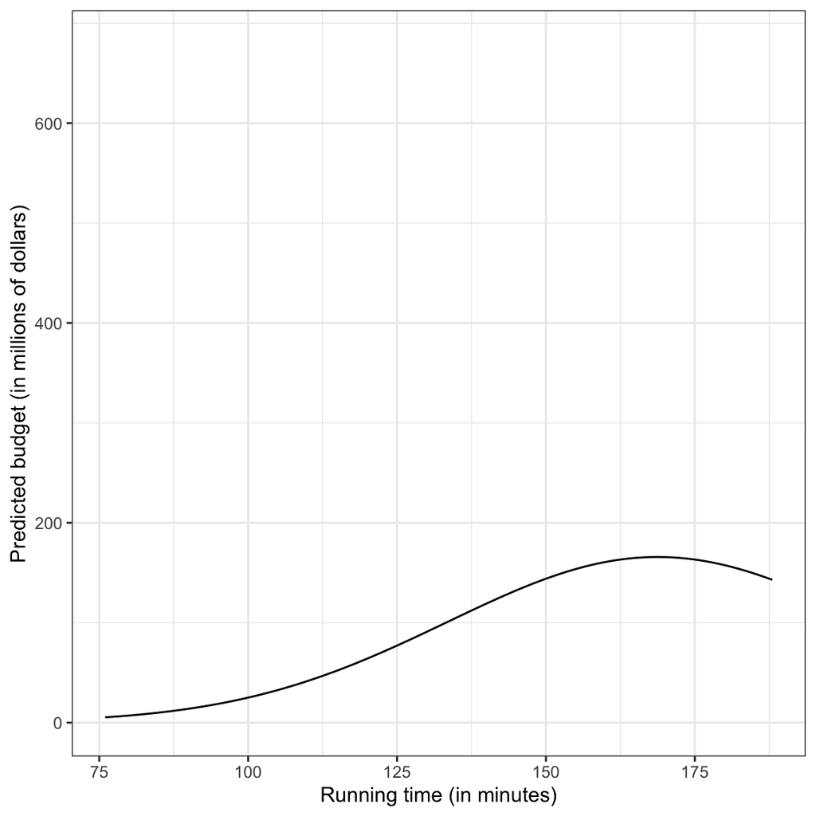

Plot of predicted budget as a function of running time for the quadratic polynomial model.

```r
# Plot
ggplot(data = movies, aes(x = length, y = budget)) +
  geom_point(alpha = 0) +
  geom_function(fun = function(x) {exp(-6.28) * exp(0.135*x) * exp(-0.0004*x^2)} ) +
  theme_bw() +
  xlab("Running time (in minutes)") +
  ylab("Predicted budget (in millions of dollars)")
```

The relationship between running time and budget is quite complicated. It combines the positive exponential growth we saw earlier with the change in curvature of the negative quadratic efect. In general longer movies have an exponentially increasing budget that begins to dimish for movies longer than approximately 170 minutes.

## Relationship between Genre and Budget

One hypothesis might be that action movies tend to have higher budgets due to the special effects they include. We will explore this hypothesis to see whether there are differences in budget between action movies and other movie genres. Since we log-transformed budget (the outcome) in the previous analysis we will need to use the log-transformed outcome in this exploration as well.

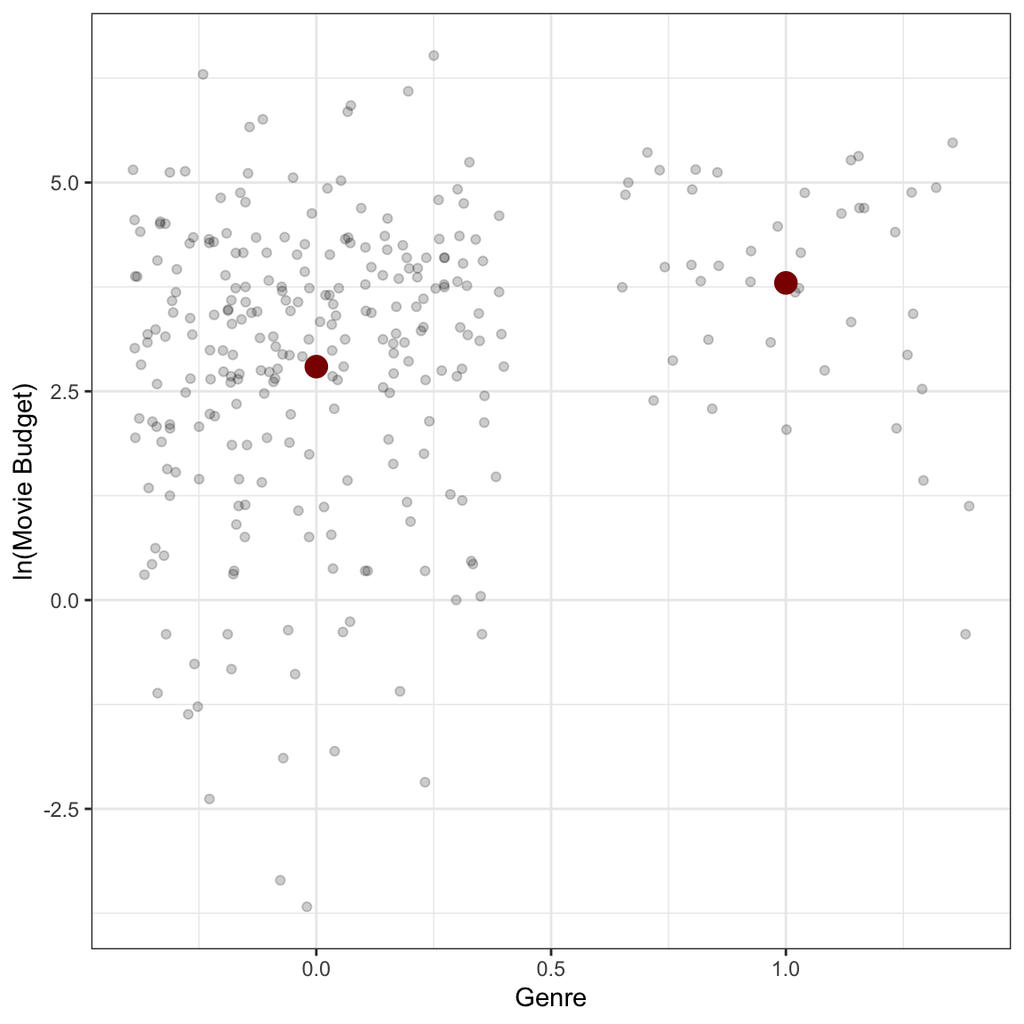

Jittered scatterplot of log-transformed budget by genre (action movie/non-action movie. The mean is displayed as a larger, red point.

```r
# Create dummy variable
movies = movies %>%
  mutate(
    action = if_else(genre == "Action", 1, 0)
  )

# Plot the observed data
ggplot(data = movies, aes(x = action, y = Lbudget)) +
  geom_jitter(alpha = 0.2) +
  stat_summary(fun = mean, geom = "point", size = 4, color = "darkred") +
    theme_bw() +
    xlab("Genre") +
    ylab("ln(Movie Budget)")
```

```r
# Compute summary statistics
movies %>%
  group_by(action) %>%
  summarize(
    M = mean(Lbudget),
    SD = sd(Lbudget)
    )
```

```
# A tibble: 2 x 3
  action     M    SD
*  <dbl> <dbl> <dbl>
1      0  2.80  1.76
2      1  3.80  1.31
```

The plot and summary statistics indicate that the log-budget for action movies is higher than for other genres in our sample. The variation in log-budgets seems roughly comparable between the two groups of movies, although it could be argued that movies in the action genre seem to have slightly less variation than the other genres.

### Regressing the Log-Transformed Budget on the Action Dummy

To examine whether the sample differences are more than we would expect because of sampling error, we will fit a model regressing the log-transformed budgets on the action dummy variable. We will also fit an intercept-only model as a comparison model to evaluate the effect of genre.

```r
# Fit the model (non-action is reference group)
lm.3 = lm(Lbudget ~ 1 + action, data = movies)

# Fit the intercept-only model
lm.0 = lm(Lbudget ~ 1, data = movies)

# Likelihood ratio test to evaluate action effect
lrtest(lm.0, lm.3)
```

```
Likelihood ratio test

Model 1: Lbudget ~ 1
Model 2: Lbudget ~ 1 + action
  #Df  LogLik Df  Chisq Pr(>Chisq)
1   2 -574.95
2   3 -568.68  1 12.532     0.0004 ***
---
Signif. codes:  0 '***' 0.001 '**' 0.01 '*' 0.05 '.' 0.1 ' ' 1
```

```r
# Model-level output
print(glance(lm.3), width = Inf)
```

```
# A tibble: 1 x 12
  r.squared adj.r.squared sigma statistic  p.value    df logLik   AIC   BIC
      <dbl>         <dbl> <dbl>     <dbl>    <dbl> <dbl>  <dbl> <dbl> <dbl>
1    0.0420        0.0387  1.70      12.7 0.000424     1  -569. 1143. 1154.
  deviance df.residual  nobs
     <dbl>       <int> <int>
1     840.         290   292
```

The model-level summary information suggests that differences in genre (action vs non-action) explains 4.2% of the variation in budget. (Remember, explaining variation in log-budget is the same as explaining variation in budget.) Although this is a small amount of variation, the empirical evidence supports including the genre effect, $\chi^2(1)=12.53$, $p=0.0004$.

```r
# Coefficient-level output
tidy(lm.3)
```

```
# A tibble: 2 x 5
  term        estimate std.error statistic  p.value
  <chr>          <dbl>     <dbl>     <dbl>    <dbl>
1 (Intercept)     2.80     0.108     25.9  1.87e-77
2 action          1.00     0.281      3.57 4.24e- 4
```

From the coefficient-level output we can write the fitted equation:

$$\ln\left(\hat{\mathrm{Budget}_i}\right) = 2.80 + 1.003(\mathrm{Action}_i)$$

### Coefficient Interpretation

As with our previous interpretations, we can offer two sets of interpretations, depending on whether we use the metric of log-budget, or back-transform to budget. Using the log-transformed metric, the coefficients can be interpreted in the exact same way as any other regression coefficients (except we use log-outcome instead of outcome):

- The intercept, $\hat{\beta_0} = 2.80$, is the average predicted log-budget for non-action movies.
- The slope associated with action movies, $\hat{\beta_1} = 1.003$, indicates that action movies have a log-budget that is 1.003-units higher than non-action movies, on average.

We can also interpret the coefficients using the metric of raw budget by back-transforming the coefficients. To back-transform, exponentiate both sides of the fitted equation. Here the back-transformed fitted equation is:

$$\begin{split}
e^{\ln\left(\hat{\mathrm{Budget}_i}\right)} &= e^{2.80 + 1.003(\mathrm{Action}_i)} \\[1ex]
\hat{\mathrm{Budget}_i} &= e^{2.80} \times e^{1.003(\mathrm{Action}_i)}
\end{split}$$

To interpret the effects (which are now interpreted using the metric of raw budget, we can substitute in the different dummy variable patterns and solve.

**Non-Action Movie**

$$\begin{split}
\hat{\mathrm{Budget}_i} &= e^{2.80} \times e^{1.003(0)}\\
&= 16.37 \times 1 \\
&= 16.37
\end{split}$$

**Action Movie**

$$\begin{split}
\hat{\mathrm{Budget}_i} &= e^{2.80} \times e^{1.003(1)}\\
&= 16.37 \times 2.73 \\
&= 44.61
\end{split}$$

When we interpret the effects of each of the coefficients,

- Non-action movies have a budget of 16.37 million dollars, on average.
- Action movies have a budget that is 2.73 TIMES the estimated budget for non-action movies, on average.

We can obtain these values directly by exponentiating the estimated regression coefficients.

```r
exp(coef(lm.3))
```

```
(Intercept)      action
  16.371205    2.725324
```

### Coefficient Interpretation: Percent Change

Unfortunately, the direct interpretation of the slope coefficients using the language of “percent change” is not trustworthy given that the absolute values of each of the estimated slope is bigger than 0.20. (This direct interpretation from the slope coefficients starts to become untrustworthy when the slope value is higher than about 0.20 or so.)

```r
coef(lm.3)
```

```
(Intercept)      action
   2.795524    1.002587
```

If we did interpret the slope directly, the (wrong) interpretation would be:

##### Interpretation

Action movies are associated with a 100.2 percent increase in budget, on average, over non-action movies.

If you want the specific percent change in budget, compute

$$\bigg\vert 1 - e^{\hat{\beta_k}}\bigg\vert$$

This can then be interpreted as a percentage increase or decrease depending on the sign of the slope coefficient.

```r
# Percent change
abs(1 - exp(1.002587))
```

```
[1] 1.725323
```

##### Interpretation

Action movies are associated with a 173 percent increase in budget, on average, over non-action movies.

Again, pay attention to the idea of “percent change” versus “percent.” In this case action movies have a budget which is 273% of non-action movies budgets, on average. This is different than the 173 percent increase in budget that we just interpreted.

# Modeling the Effects of Running Time and Genre

We can now explore a set of final models that includes the effects of both running time and genre (whether or not the movie is an action movie). We begin by evaluating the main effects of these predictors by fitting a model that includes the linear and quadratic effect of running time, as well as the genre effect.

```r
# Fit the model (non-action is reference group)
lm.4 = lm(Lbudget ~ 1 + length + I(length^2) + action, data = movies)

# Likelihood ratio test (partial effect of genre)
lrtest(lm.3, lm.4)
```

```
Likelihood ratio test

Model 1: Lbudget ~ 1 + action
Model 2: Lbudget ~ 1 + length + I(length^2) + action
  #Df  LogLik Df  Chisq Pr(>Chisq)
1   3 -568.68
2   5 -547.89  2 41.592  9.301e-10 ***
---
Signif. codes:  0 '***' 0.001 '**' 0.01 '*' 0.05 '.' 0.1 ' ' 1
```

```r
# Likelihood ratio test (partial quadratic effect of running time)
lm.5 = lm(Lbudget ~ 1 + length + action, data = movies)
lrtest(lm.5, lm.4)
```

```
Likelihood ratio test

Model 1: Lbudget ~ 1 + length + action
Model 2: Lbudget ~ 1 + length + I(length^2) + action
  #Df  LogLik Df  Chisq Pr(>Chisq)
1   4 -550.28
2   5 -547.89  1 4.7938    0.02856 *
---
Signif. codes:  0 '***' 0.001 '**' 0.01 '*' 0.05 '.' 0.1 ' ' 1
```

```r
# Model-level output
glance(lm.4)
```

```
# A tibble: 1 x 12
  r.squared adj.r.squared sigma statistic  p.value    df logLik   AIC   BIC
      <dbl>         <dbl> <dbl>     <dbl>    <dbl> <dbl>  <dbl> <dbl> <dbl>
1     0.169         0.161  1.59      19.6 1.45e-11     3  -548. 1106. 1124.
# … with 3 more variables: deviance <dbl>, df.residual <int>, nobs <int>
```

The empirical evidence supports the model that includes the linear and quadratic effects of running time and the effect of genre. This model explains 16.9% of the variation in movie budgets.

```r
# Coefficient-level output
tidy(lm.4)
```

```
# A tibble: 4 x 5
  term         estimate std.error statistic p.value
  <chr>           <dbl>     <dbl>     <dbl>   <dbl>
1 (Intercept) -5.56      2.35         -2.37 0.0187
2 length       0.121     0.0410        2.95 0.00339
3 I(length^2) -0.000380  0.000174     -2.18 0.0298
4 action       0.807     0.265         3.04 0.00255
```

From the coefficient-level output we can write the fitted equation:

$$\ln\left(\hat{\mathrm{Budget}_i}\right) = -5.56 + 0.12(\mathrm{Running~Time}_i) - 0.0004(\mathrm{Running~Time}_i^2) + 0.81(\mathrm{Action}_i)$$

Back-transforming to the metric of budget, the fitted equation is:

$$\hat{\mathrm{Budget}_i} = e^{-5.56} \times e^{0.12(\mathrm{Running~Time}_i)} \times e^{-0.0004(\mathrm{Running~Time}_i^2)} \times e^{0.81(\mathrm{Action}_i)}$$

Interpreting the effects of running time and action:

```r
# Exponentiate coefficients
exp(coef(lm.4))
```

```
(Intercept)      length I(length^2)      action
0.003840949 1.128789038 0.999619650 2.240484088
```

- After controlling for whether or not a movie is an action movie, the effect of running time on budget varies by running time. (Since the quadratic effect of running time is an interaction, we only offer a general interpretation of that interaction effect.)
- After controlling for differences in running time, action movies have a budget that is 2.25 times that of non-action movies, on average.

To better understand the nature of both of these effects, we find the fitted equations for action and non-action movies and then plot the two fitted curves using two `geom_function()` layers.

**Non-Action**

$$\begin{split}
\hat{\mathrm{Budget}_i} &= e^{-5.56} \times e^{0.12(\mathrm{Running~Time}_i)} \times e^{-0.0004(\mathrm{Running~Time}_i^2)} \times e^{0.81(0)} \\[1ex]
&= e^{-5.56} \times e^{0.12(\mathrm{Running~Time}_i)} \times e^{-0.0004(\mathrm{Running~Time}_i^2)}
\end{split}$$

**Action**

$$\begin{split}
\hat{\mathrm{Budget}_i} &= e^{-5.56} \times e^{0.12(\mathrm{Running~Time}_i)} \times e^{-0.0004(\mathrm{Running~Time}_i^2)} \times e^{0.81(1)} \\[1ex]
&= e^{-5.56} \times e^{0.12(\mathrm{Running~Time}_i)} \times e^{-0.0004(\mathrm{Running~Time}_i^2)} \times e^{0.81} \\[1ex]
&= e^{-5.56} \times e^{0.81} \times e^{0.12(\mathrm{Running~Time}_i)} \times e^{-0.0004(\mathrm{Running~Time}_i^2)} \\[1ex]
&= e^{-5.56+ 0.81} \times e^{0.12(\mathrm{Running~Time}_i)} \times e^{-0.0004(\mathrm{Running~Time}_i^2)} \\[1ex]
&= e^{-4.75} \times e^{0.12(\mathrm{Running~Time}_i)} \times e^{-0.0004(\mathrm{Running~Time}_i^2)} \\[1ex]
\end{split}$$

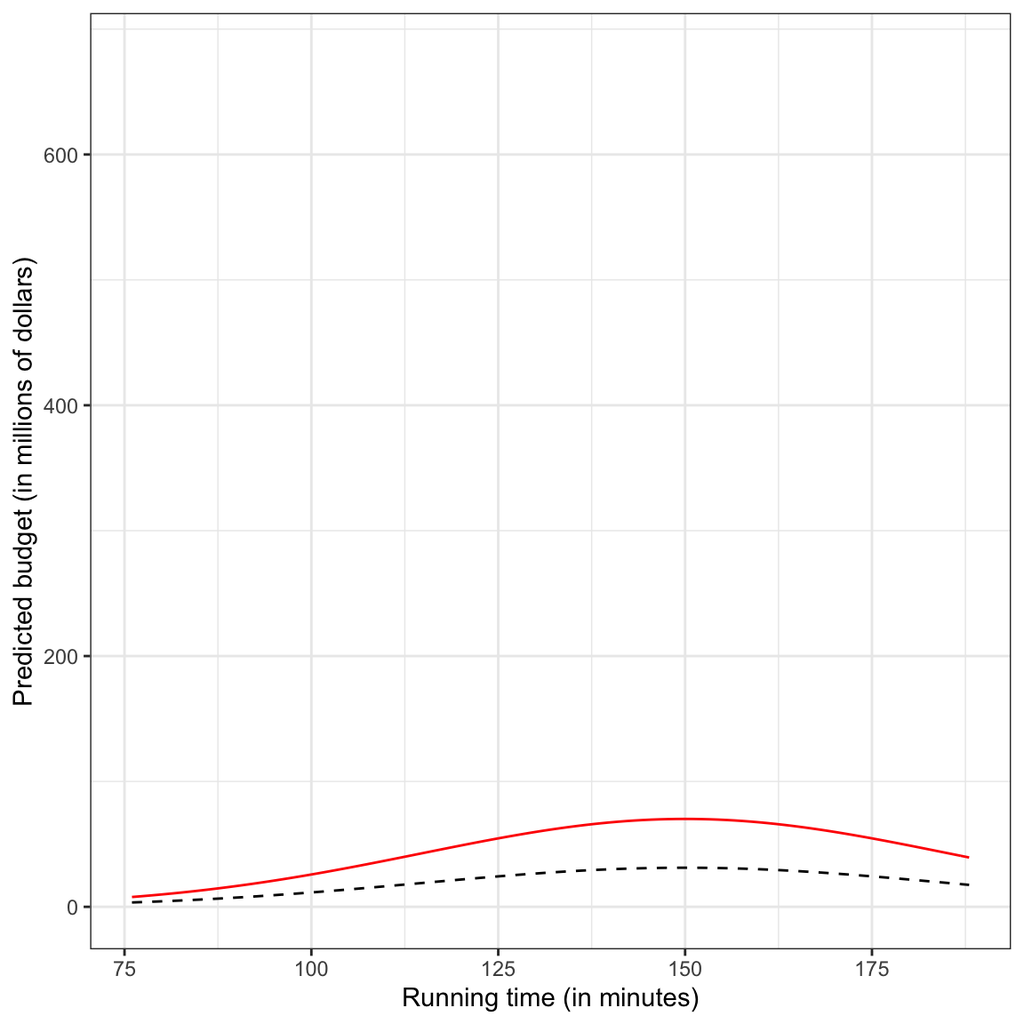

The fitted curves from the model with linear and quadratic effects of running time for both action movies (red, solid line) and non-action movies (black, dashed line) are displayed.

```r
# Plot
ggplot(data = movies, aes(x = length, y = budget)) +
  geom_point(alpha = 0) +
  geom_function(fun = function(x) {exp(-5.56) * exp(0.12*x) * exp(-0.0004*x^2)},
                color = "black", linetype = "dashed") +
  geom_function(fun = function(x) {exp(-4.75) * exp(0.12*x) * exp(-0.0004*x^2)},
                color = "red", linetype = "solid") +
  theme_bw() +
  xlab("Running time (in minutes)") +
  ylab("Predicted budget (in millions of dollars)")
```

This plot suggests that there is a complex curvilinear relationship between running time and budget for both action and non-action movies. In general, the effect of running time on budget increases for both types of movies with longer running times until about 150 minutes (approximate *x*-coordinate of the vertex) then the effect of running time has an increasing negative effect on budget. Furthermore, action movies have a higher average budget than non-action movies, allow the difference in budget changes as a function of running time.

Note that although we fitted a main effects model, once we back-transform from an additive to a multiplicative relationship, the two fitted curves are no longer parallel. If we had plotted running time as a function of log-budget then the two curves would have been parallel.

We can also evaluate whether or not there is an interaction between running time and genre. Because there are multiple effects of running time in the model (linear and qudratic) there are multiple interaction models we can consider. The first potential interaction model includes an interaction between the linear effect of running time and genre.

$$\ln\left(\mathrm{Budget}_i\right) = \beta_0 + \beta_1(\mathrm{Running~Time}_i) + \beta_2(\mathrm{Running~Time}_i^2) + \beta_3(\mathrm{Genre}_i) + \beta_4(\mathrm{Running~Time}_i)(\mathrm{Genre}_i) + \epsilon_i$$

where $\epsilon_i\overset{\mathrm{i.i.d.}}{\sim}\mathcal{N}(0,\sigma^2_{\epsilon})$. The second potential interaction model includes an interaction between both the linear effect of running time and genre, and the quadratic effect of running time and genre.

$$\begin{split}
\ln\left(\mathrm{Budget}_i\right) = &\beta_0 + \beta_1(\mathrm{Running~Time}_i) + \beta_2(\mathrm{Running~Time}_i^2) + \beta_3(\mathrm{Genre}_i) \\
&+ \beta_4(\mathrm{Running~Time}_i)(\mathrm{Genre}_i) + \beta_5(\mathrm{Running~Time}_i^2)(\mathrm{Genre}_i) + \epsilon_i
\end{split}$$

where $\epsilon_i\overset{\mathrm{i.i.d.}}{\sim}\mathcal{N}(0,\sigma^2_{\epsilon})$. If we include the interaction between the quadratic effect of running time and genre, we have to also include the interaction between the linear effect of running time and genre. This is because the interaction between the linear effect of running time and genre is a lower order term of the interaction between the quadratic effect of running time and genre. (The rule is, if we include an interaction, we must include all lower order constituent terms if we want interpretable results.)

Since the main-effect model is nested in the first interaction model, which is in turn nested in the second interaction model, we can use a series of likelihood ration tests to evaluate the potential interaction effects.

```r
# Fit the first interaction model
lm.6 = lm(Lbudget ~ 1 + length + I(length^2) + action + length:action, data = movies)

# Fit the second interaction model
lm.7 = lm(Lbudget ~ 1 + length + I(length^2) + action + length:action + I(length^2):action, data = movies)

# Likelihood ratio tests
lrtest(lm.4, lm.6, lm.7)
```

```
Likelihood ratio test

Model 1: Lbudget ~ 1 + length + I(length^2) + action
Model 2: Lbudget ~ 1 + length + I(length^2) + action + length:action
Model 3: Lbudget ~ 1 + length + I(length^2) + action + length:action +
    I(length^2):action
  #Df  LogLik Df  Chisq Pr(>Chisq)
1   5 -547.89
2   6 -547.54  1 0.6960     0.4041
3   7 -546.49  1 2.0929     0.1480
```

Based on these tests, the empirical evidence does not support including interaction effects between running time and genre. We would adopt the main effects model as our “final” model.

## Presentation of the Candidate Models

In reporting your candidate models, consider the story you want to present. It is not necessary to present every model you fitted in the analysis in a publication.[^1] Here, the following models constitute the primary narrative that I would write about in a publication:

- **Model A:** Main effect of running time (Linear)
- **Model B:** Main effects of running time (Linear and Quadratic)
- **Model C:** Main effect of genre
- **Model D:** Main effects of running time (Linear and Quadratic) and genre
- **Model E:** Main effects of running time (Linear and Quadratic) and genre, and interaction effect between running time (Linear) and genre

Here for example is a table that I might present.

Five candidate models predicting variation in movie budgets. The action movie predictor was dummy-coded using a non-action movies as the reference group. In all models, the outcome was log-transformed using the natural logarithm.

| Predictor | Model A | Model B | Model C | Model D | Model E |
| --- | --- | --- | --- | --- | --- |
| Coefficient-level estimates |  |  |  |  |  |
| Running time (Linear) | 0.80 (0.25) | 0.14 (0.04) |  | 0.12 (0.04) | 0.12 (0.04) |
| Running time (Quadratic) |  | -0.0004 (0.0002) |  | -0.0004 (0.0002) | -0.0004 (0.0002) |
| Action movie |  |  | 1.00 (0.28) | 0.81 (0.27) | -0.60 (1.71) |
| Running time (Linear) x Action movie |  |  |  |  | 0.01 (0.02) |
| Constant | -32.83 (26.15) | -6.28 (2.37) | 2.80 (0.11) | -5.56 (2.35) | -5.26 (2.38) |
| Model-level estimates |  |  |  |  |  |
| R<sup>2</sup> | 0.035 | 0.142 | 0.042 | 0.169 | 0.171 |
| Residual Standard Error | 76.23 | 1.61 | 1.70 | 1.59 | 1.59 |

The set of likelihood ratio tests could be included in prose, or a second table. The evidence from these tests (log-likelihood, $\chi^2$-value, *df*, and *p*-value) could also be included in one or more rows under “model-level evidence” in the table presenting the previous regression table. Here we present the evidence in a second table.

Results from a likelihood ratio test comparing five candidate models.

| Model | Parameters | ln(Lik) | *df* | $\chi^2$ | *p* |
| --- | --- | --- | --- | --- | --- |
| Model A | 3 | -1678.78 |  |  |  |
| Model B | 4 | -552.51 | 1 | 2252.55 | <0.001 |
| Model C | 3 | -568.68 | -1 | 32.34 | <0.001 |
| Model D | 5 | -547.89 | 2 | 41.59 | <0.001 |
| Model E | 6 | -547.54 | 1 | 0.70 | 0.404 |

[^1]: It is, however, good ethical practice to make the script file you used available to other researchers. This would include ALL the models fitted and analyses performed, even if they didn’t make the final paper.